# Session 1: Statistical and Machine Learning Models

## Multivariate Outlier Detection

- We consider variables: `mpg`, `disp`, `hp`, `wt` for multivariate outlier detection

### Mahalanobis Distance Method

- Steps
  - Find the covariance of the variables
  - Find the mean vector of the variables
  - Evaluate the `mahalanobis` distance of each observation
  - Find Chi-square cut off value with with $\alpha = 0.05$
  - Test `mahalanobis` distance is more than the Chi-square cut off
- Observations `17` and `31` are outliers

```r
numeric_vars = mtcars[, c("mpg", "disp", "hp", "wt")]
cov_matrix = cov(numeric_vars)
mean_vector = colMeans(numeric_vars)

# Calculate Mahalanobis distance for each car
mtcars$mahal_dist = mahalanobis(numeric_vars, mean_vector, cov_matrix)

# Use Chi-Square critical value (df = 4, alpha = 0.05) as threshold
chi_crit = qchisq(0.95, df = ncol(numeric_vars))
which(mtcars$mahal_dist > chi_crit)
```

```
## [1] 17 31
```

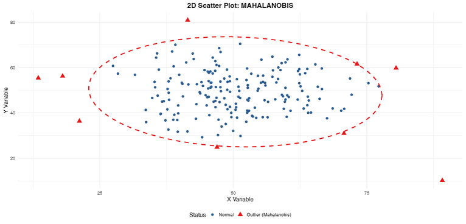

### Isolation Forest Method

- This is an machine learning method related to Random Forest Regression
- Use `isolation.forest` function under `isoforest’ package
- Her we flag the top $10\%$ highest anomaly scores as outliers
- Observation `15`,`16`,`19` and `20` are outliers

[output not shown]

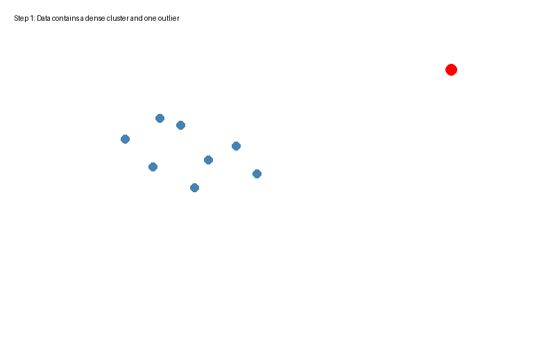

```r
set.seed(42)
iso_model = isolation.forest(numeric_vars, ntrees = 100)

# Predict anomaly scores (higher score = more anomalous)
mtcars$iso_score = predict(iso_model, numeric_vars)

# Flag the top 10% highest anomaly scores as outliers
which(mtcars$iso_score > quantile(mtcars$iso_score, 0.90))
```